# TA1 : EDA best of

TA course: Mar.15.2018,Lai

## Tips 1 : table()

table() 可用於計算一維向量中的數值個數、也可用於data.frame，甚至是產生二維以上的列連表做類別資料分析。table()後面通常會接barplot()做長條圖的視覺化。

```r
attach(iris)
library(ggplot2)
library(magrittr)
#計算Species各有幾個
table(Species)
```

```
## Species
##     setosa versicolor  virginica
##         50         50         50
```

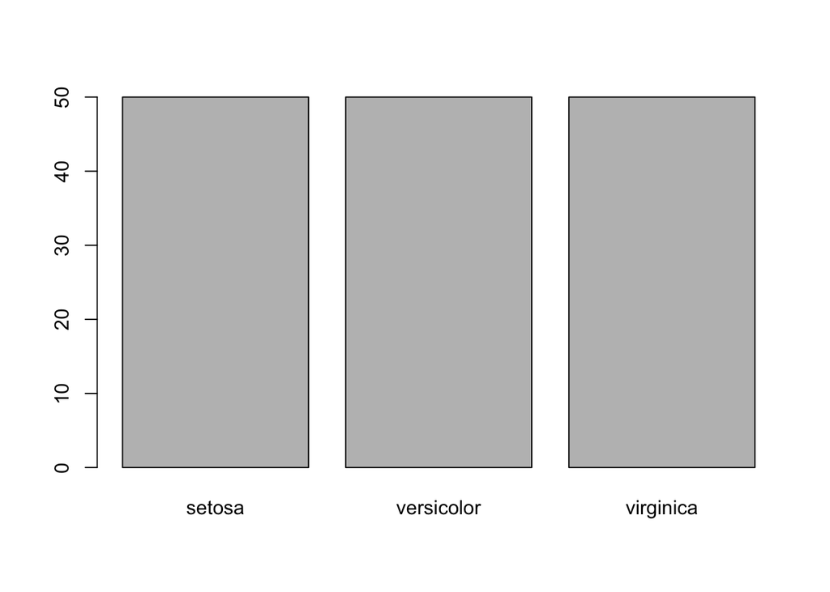

```r
#畫長條圖
table(Species) %>% barplot()
```

做資料篩選時確認個數很有用

```r
#Petal.Length大於5的個數
t1 = table(Petal.Length>5)
#或者巧妙的計算比率
t2 = table(Petal.Length>5)/length(Petal.Length)
t1;t2
```

```
##
## FALSE  TRUE
##   108    42
```

```
##
## FALSE  TRUE
##  0.72  0.28
```

ps.可用names()函數修改table名稱

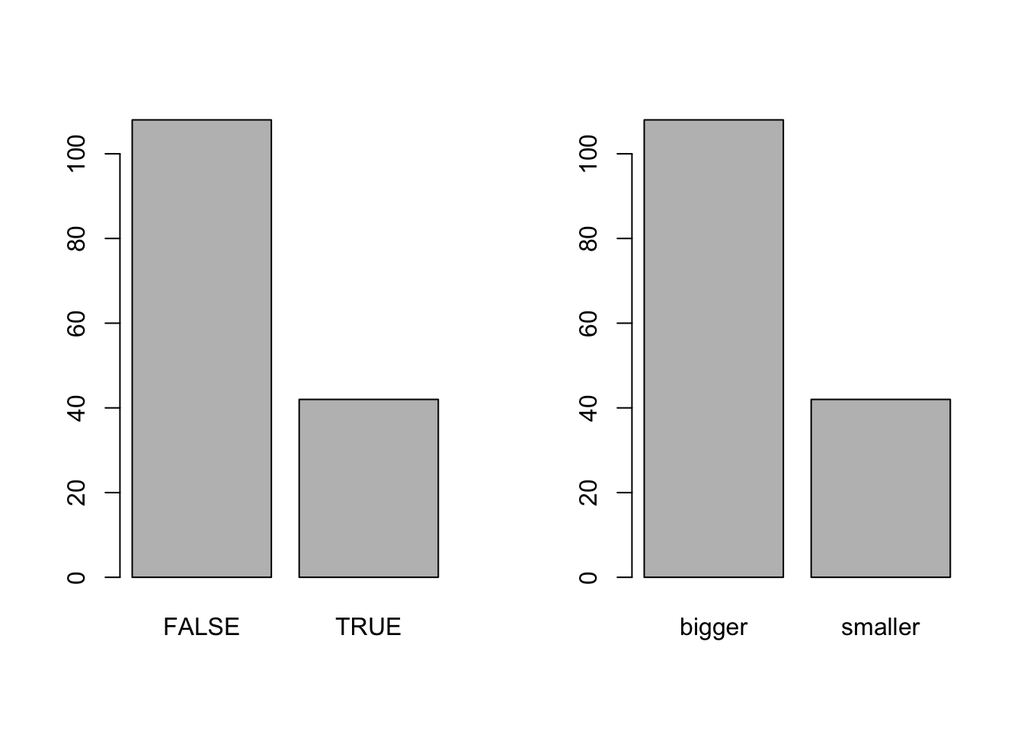

```r
t1 = table(Petal.Length>5)
t2 = table(Petal.Length>5)
names(t2) = c("bigger","smaller")
par(mfrow=c(1,2))
barplot(t1);barplot(t2)
```

二維列連表範例：2017/8/9的政大員工出缺席表

```r
#生產行一一家人
sin_bros = sapply(1:50,function(x){
  paste("行",x,sep="")
})
set.seed(689)
df1 = data.frame(name=sin_bros,
                 late=sample(c("遲到","準時"),50,replace = T),
                 overtime = sample(c("加班","早退","準時打卡"),50,r=T),
                 salary=(salary<-rpois(50,25)*1000),
                 prev_salary = round(salary*0.88+rnorm(50,1000,2000),-2),
                 iq = rpois(50,110),
                 gender=factor(sample(c("M","F"),50,r=T)),
                 hobby = factor(sample(c("cook","read","learn Eng","swim"),50,r=T))
                 )

head(df1);table(df1$late,df1$overtime)
```

|  | name | late | overtime | salary | prev_salary | iq | gender | hobby |
| --- | --- | --- | --- | --- | --- | --- | --- | --- |
| 1 | 行1 | 準時 | 早退 | 27000 | 20400 | 105 | F | learn Eng |
| 2 | 行2 | 遲到 | 準時打卡 | 22000 | 22400 | 118 | F | learn Eng |
| 3 | 行3 | 遲到 | 早退 | 24000 | 24200 | 98 | F | swim |
| 4 | 行4 | 準時 | 加班 | 13000 | 13000 | 98 | M | cook |
| 5 | 行5 | 準時 | 準時打卡 | 25000 | 23500 | 112 | F | cook |
| 6 | 行6 | 遲到 | 早退 | 20000 | 20100 | 107 | F | read |

```
##
##        加班 早退 準時打卡
##   遲到    6   10        8
##   準時   11    6        9
```

補充：table()函數會回傳一個table類別(用class()檢查)，可以用as.data.frame()將其轉為data.frame，以利後續分析或使用ggplot()

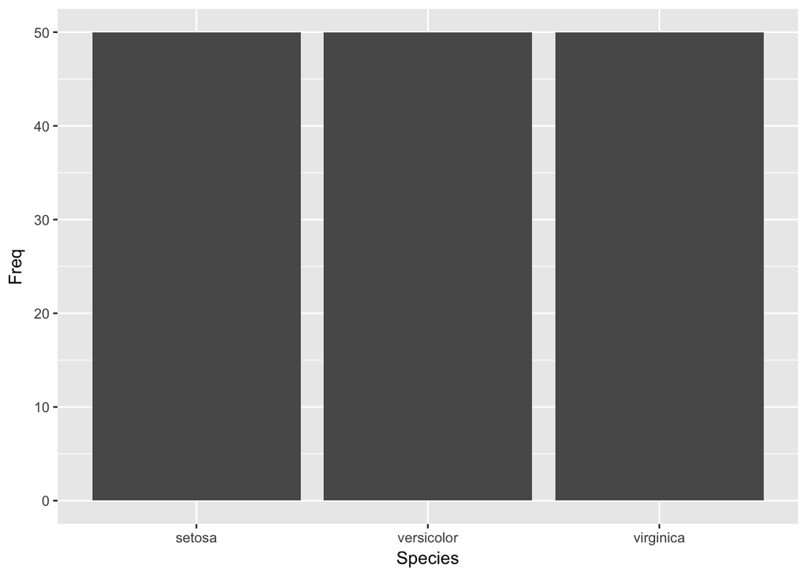

```r
table(Species) %>% as.data.frame() %>% ggplot(aes(x=Species, y=Freq)) +
  geom_bar(stat="identity")
```

## Tips 2 : which()

which()可以用來篩選觀測值，找出觀測值的index，這步驟很重要一定要會rrr

```r
#誰被霸凌
which(df1$salary<22000)
```

```
##  [1]  4  6 11 27 29 32 34 38 39 46 47 50
```

```r
#用length()計算個數
which(df1$salary <22000) %>% length()
```

```
## [1] 12
```

也可以拿來篩選data.frame(或者使用subset() )

```r
## 篩選data.frame()
## ps. 篩選結果若要重複使用，可以用變數儲存起來，像是這樣:
## sel = which(df1$salary<22000)
## df1[sel,]
df1[which(df1$salary<22000),]
```

|  | name | late | overtime | salary | prev_salary | iq | gender | hobby |
| --- | --- | --- | --- | --- | --- | --- | --- | --- |
| 4 | 行4 | 準時 | 加班 | 13000 | 13000 | 98 | M | cook |
| 6 | 行6 | 遲到 | 早退 | 20000 | 20100 | 107 | F | read |
| 11 | 行11 | 遲到 | 早退 | 16000 | 15800 | 117 | M | swim |
| 27 | 行27 | 遲到 | 加班 | 19000 | 18600 | 117 | M | swim |
| 29 | 行29 | 遲到 | 加班 | 19000 | 19200 | 94 | F | swim |
| 32 | 行32 | 準時 | 加班 | 15000 | 11600 | 107 | F | swim |
| 34 | 行34 | 遲到 | 準時打卡 | 18000 | 19800 | 97 | F | swim |
| 38 | 行38 | 遲到 | 早退 | 10000 | 9500 | 105 | F | read |
| 39 | 行39 | 遲到 | 加班 | 19000 | 18900 | 122 | M | read |
| 46 | 行46 | 遲到 | 早退 | 20000 | 17700 | 105 | M | learn Eng |

[output cut: 2 more lines]

如果要進行複合性的分析，使用邏輯運算子&(and)，|(或):

```r
which(df1$gender=='F' & df1$iq>120 & df1$salary>22000)  %>% df1[.,]
```

|  | name | late | overtime | salary | prev_salary | iq | gender | hobby |
| --- | --- | --- | --- | --- | --- | --- | --- | --- |
| 24 | 行24 | 準時 | 早退 | 26000 | 26800 | 132 | F | read |

```r
# 補充潮潮寫法
# df1 %$% which(gender=='F' & iq>1020 & salary>22000) %>% df1[.,]
```

## Tips 3 : aggregate()

透過類別變數將data分組，並計算敘述統計，之後會其它套件可能就不會用了qq

```r
aggregate(salary~hobby,mean ,data=df1)
```

| hobby | salary |
| --- | --- |
| cook | 26214.29 |
| learn Eng | 23888.89 |
| read | 23066.67 |
| swim | 23500.00 |

## Tips 4 : summary()

計算最重要的幾個敘述統計，一次全包豪爽

```r
df1$salary %>% summary()
```

```
##    Min. 1st Qu.  Median    Mean 3rd Qu.    Max.
##   10000   22000   24000   24200   28000   36000
```

也可以這樣寫，看得懂嗎?

```r
male = which(df1$gender=="M")
female = which(df1$gender=='F')
df1 %$% summary(salary[male]) - summary(salary[female])
```

```
##    Min. 1st Qu.  Median    Mean 3rd Qu.    Max.
##    3000    2000    2000     640    1000   -5000
```

## Tips 5 : 散佈圖 plot()

看兩個變數的散佈趨勢

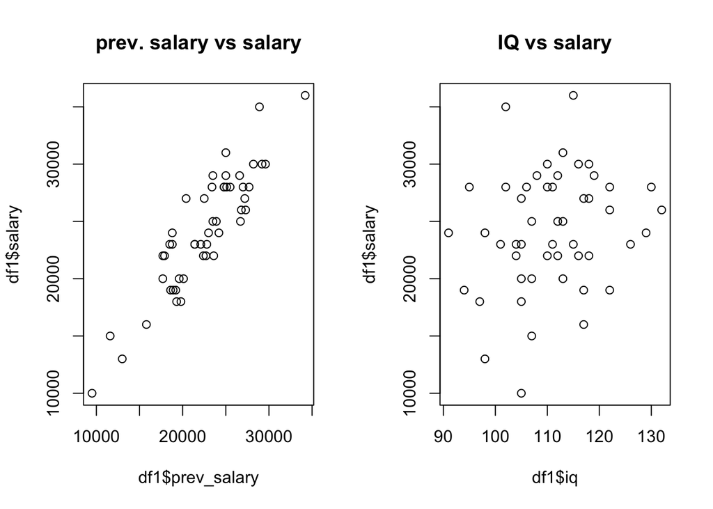

```r
par(mfrow=c(1,2))
#薪水與上一份工作的薪水相關嗎
plot(df1$prev_salary,df1$salary,main="prev. salary vs salary")
#薪水與IQ相關嗎
plot(df1$iq,df1$salary,main="IQ vs salary")
```

ggplot2 的分組圖表 (想用ggplot2，就去google “ggplot2”+圖表，就有教學與程式可以抄)

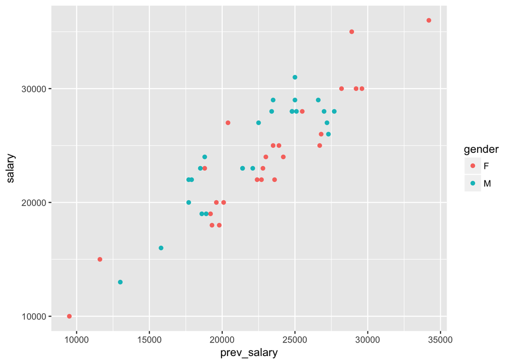

```r
ggplot(df1, aes(x=prev_salary, y=salary, color=gender)) +
  geom_point()
```

其實R內建繪圖函數也能辦到，但要注意X與Y的範圍(透過參數xlim,ylim去調整)，仔細比較一下兩張圖的不同！

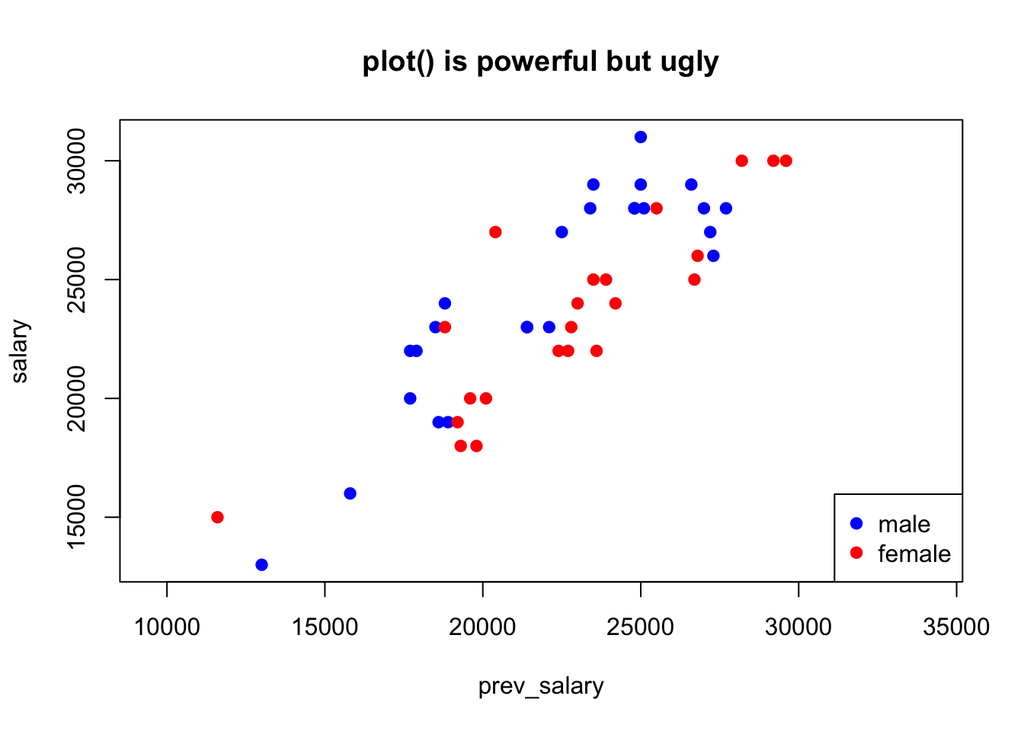

```r
df1[male,] %$% plot(prev_salary,salary,pch=19,col="blue",
                    xlim=c(min(df1$prev_salary),max(df1$prev_salary)),
                    main="plot() is powerful but ugly")
df1[female,] %$% points(prev_salary,salary,pch=19,col="red")
legend("bottomright",c("male","female"),col=c("blue","red"),pch=19)
```

## Tips 6 : 分配圖: hist()、density()

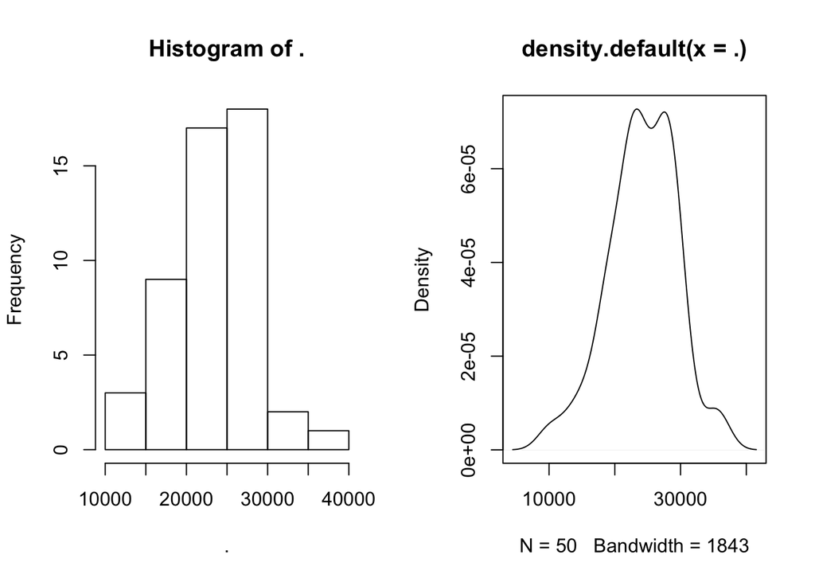

```r
par(mfrow=c(1,2))
#直方圖
df1$salary %>% hist()
#平滑過的分配圖
df1$salary %>% density() %>% plot()
```